# Practical Machine Learining Class Project

Nick Orka

3/3/2020

## Overview

One thing that people regularly do is quantify how much of a particular activity they do, but they rarely quantify how well they do it. A goal of the project is to use data from accelerometers on the belt, forearm, arm, and dumbell of 6 participants and to predict the manner in which they did the exercise. This is the “classe” variable in the training set.

## Data preprocessing

The training data for this project are available here:  
https://d396qusza40orc.cloudfront.net/predmachlearn/pml-training.csv

The test data are available here:  
https://d396qusza40orc.cloudfront.net/predmachlearn/pml-testing.csv

The data for this project come from this source: http://web.archive.org/web/20161224072740/http:/groupware.les.inf.puc-rio.br/har.

### Data summary

The initial data have NA data that required to be cleaned:

```r
dim(training)
```

```
## [1] 19622   160
```

```r
dim(testing)
```

```
## [1]  20 160
```

### Cleaning data

Cleaned data:

```r
var_names <- names(training)
naNames <- names(training[, colSums(is.na(training)) > 0])
var_names <- var_names[!var_names %in% naNames]
var_names <- var_names[!grepl("X|timestamp|window", var_names)]
training <- training[, var_names]
classe <- training$classe
training <- training[, sapply(training, is.numeric)]
var_names <- names(training)
training$classe <- classe
testing <- testing[, var_names]
dim(training)
```

```
## [1] 19622    53
```

```r
dim(testing)
```

```
## [1] 20 52
```

### Create validation dataset

```r
set.seed(34562)
isTrain <- createDataPartition(training$classe, p = .7, list = F)
validating <- training[-isTrain, ]
training <- training[isTrain,]
dim(validating)
```

```
## [1] 5885   53
```

```r
dim(training)
```

```
## [1] 13737    53
```

## Prediction model

```r
control <- caret::trainControl(method = "cv", 5)
model <- caret::train(classe ~ ., data = training, method = "rf", trControl = control, ntree = 250, localImp = TRUE)
model
```

```
## Random Forest
##
## 13737 samples
##    52 predictor
##     5 classes: 'A', 'B', 'C', 'D', 'E'
##
## No pre-processing
## Resampling: Cross-Validated (5 fold)
## Summary of sample sizes: 10989, 10990, 10989, 10991, 10989
## Resampling results across tuning parameters:
##
##   mtry  Accuracy   Kappa
##    2    0.9900269  0.9873832
##   27    0.9909734  0.9885804
##   52    0.9842034  0.9800127
##
## Accuracy was used to select the optimal model using the largest value.
## The final value used for the model was mtry = 27.
```

Then, we estimate the performance of the model on the validation data set.

```r
p <- predict(model, validating)
confusionMatrix(validating$classe, p)
```

```
## Confusion Matrix and Statistics
##
##           Reference
## Prediction    A    B    C    D    E
##          A 1673    1    0    0    0
##          B   11 1128    0    0    0
##          C    0    9 1015    2    0
##          D    0    0   15  948    1
##          E    0    1    3    6 1072
##
## Overall Statistics
##
##                Accuracy : 0.9917
##                  95% CI : (0.989, 0.9938)
##     No Information Rate : 0.2862
##     P-Value [Acc > NIR] : < 2.2e-16
##
##                   Kappa : 0.9895
##
##  Mcnemar's Test P-Value : NA
##
## Statistics by Class:
##
##                      Class: A Class: B Class: C Class: D Class: E
## Sensitivity            0.9935   0.9903   0.9826   0.9916   0.9991
## Specificity            0.9998   0.9977   0.9977   0.9968   0.9979
## Pos Pred Value         0.9994   0.9903   0.9893   0.9834   0.9908
## Neg Pred Value         0.9974   0.9977   0.9963   0.9984   0.9998
## Prevalence             0.2862   0.1935   0.1755   0.1624   0.1823
## Detection Rate         0.2843   0.1917   0.1725   0.1611   0.1822
## Detection Prevalence   0.2845   0.1935   0.1743   0.1638   0.1839
## Balanced Accuracy      0.9966   0.9940   0.9902   0.9942   0.9985
```

```r
accuracy <- postResample(p, validating$classe)
accuracy
```

```
##  Accuracy     Kappa
## 0.9916737 0.9894659
```

```r
oose <- 1 - as.numeric(confusionMatrix(validating$classe, p)$overall[1])
oose
```

```
## [1] 0.008326253
```

So, the estimated accuracy of the model is 99.17% and the estimated out-of-sample error is 0.83%. I have chosen Random forest due to several factors: 1) you can get feature importance; 2) it is a robust method; 3) you need not care about distribution; 4) if you alter your RF well, it will not be very time-consuming.

## Predicting for Test Data Set

Now, we apply the model to the original testing data set downloaded from the data source.

```r
result <- predict(model, testing)
result
```

```
##  [1] B A B A A E D B A A B C B A E E A B B B
## Levels: A B C D E
```

## Appendix: Figures

### 1. Variable importance

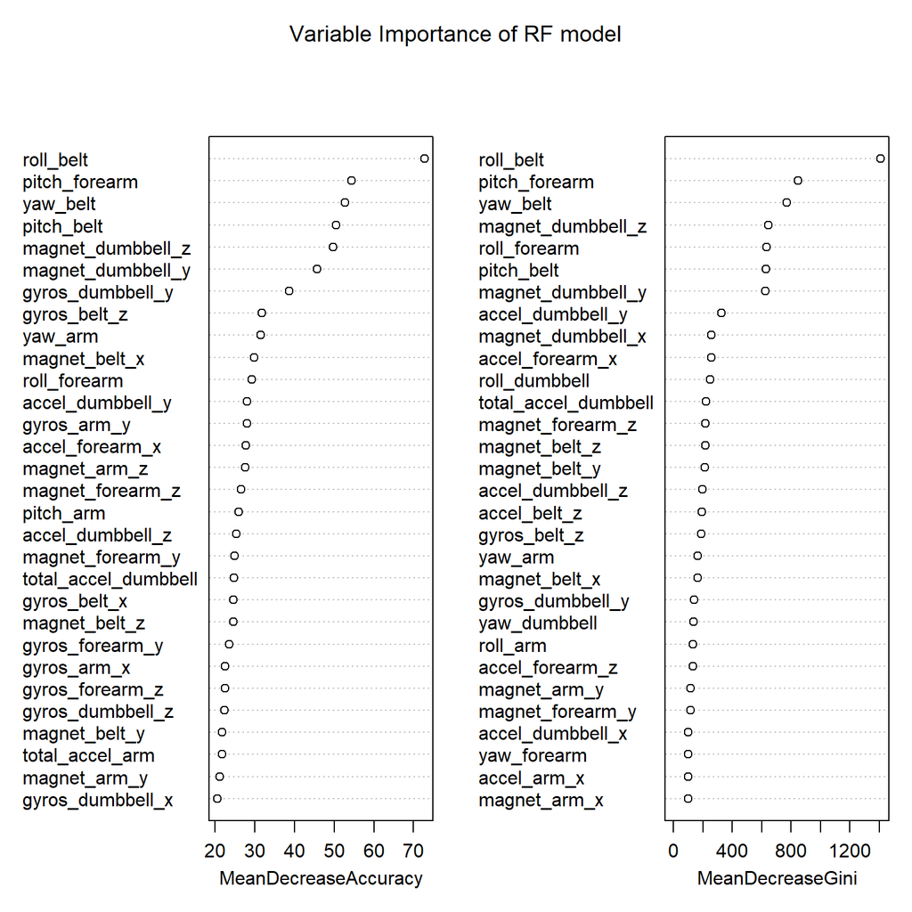

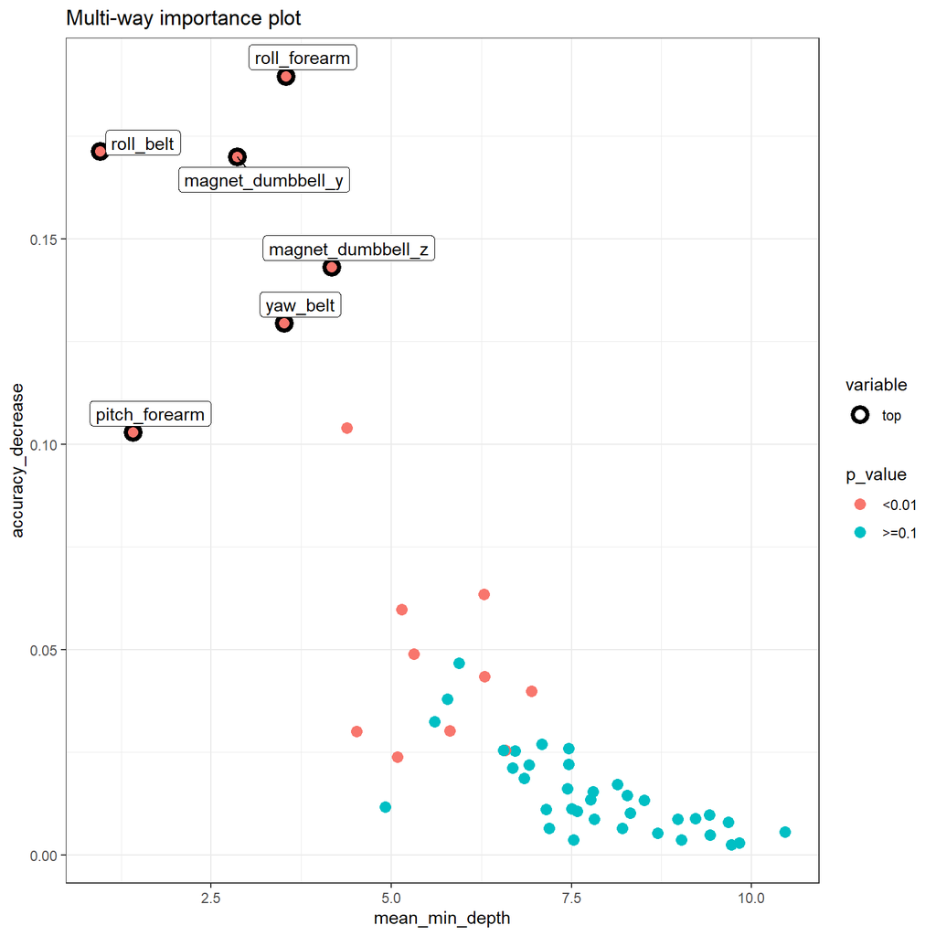

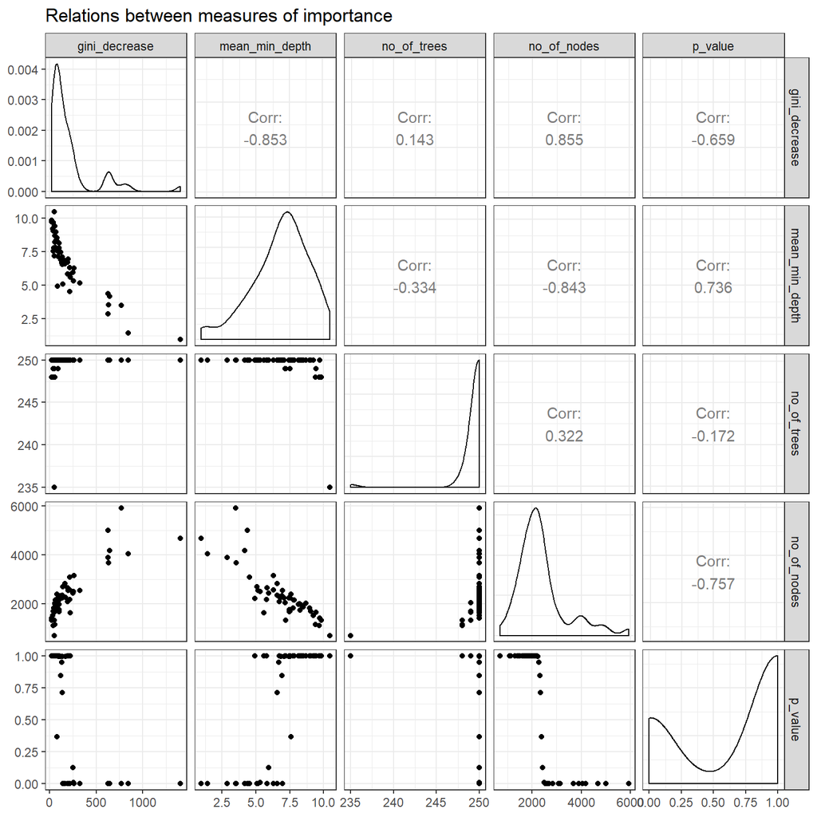

### 2. Correlation Matrix Visualization

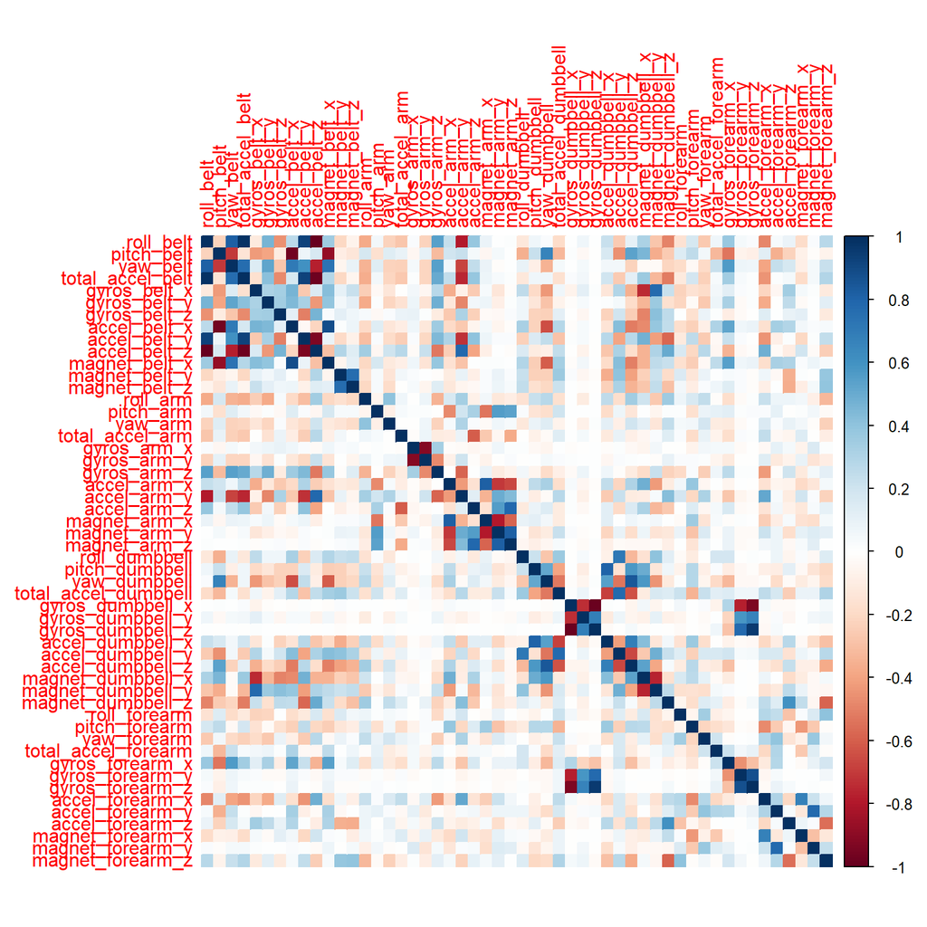

### 3. Decision Tree Visualization

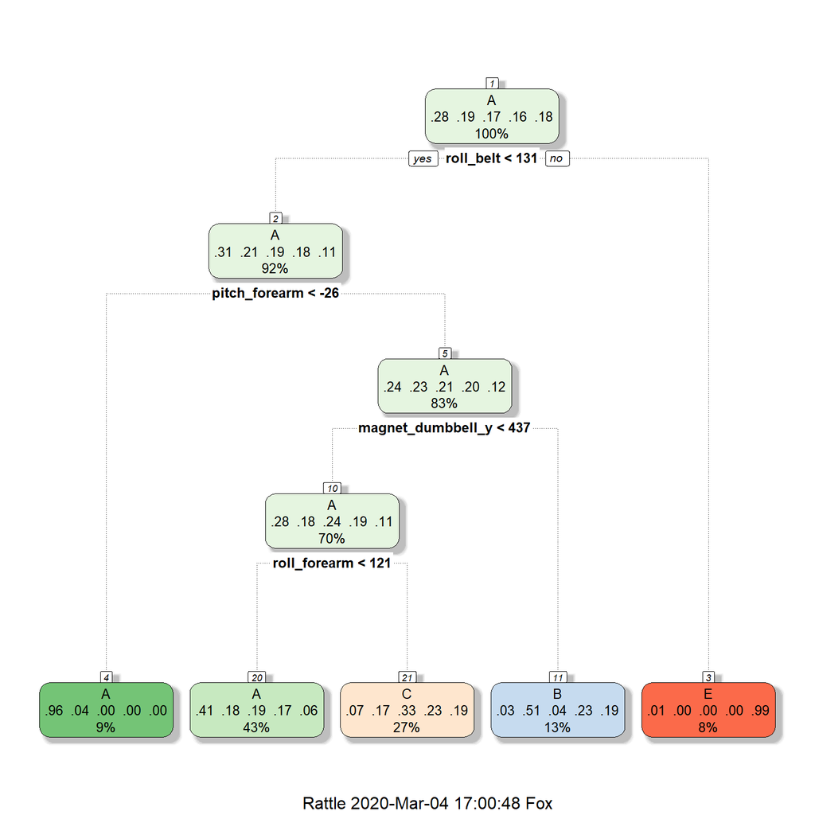

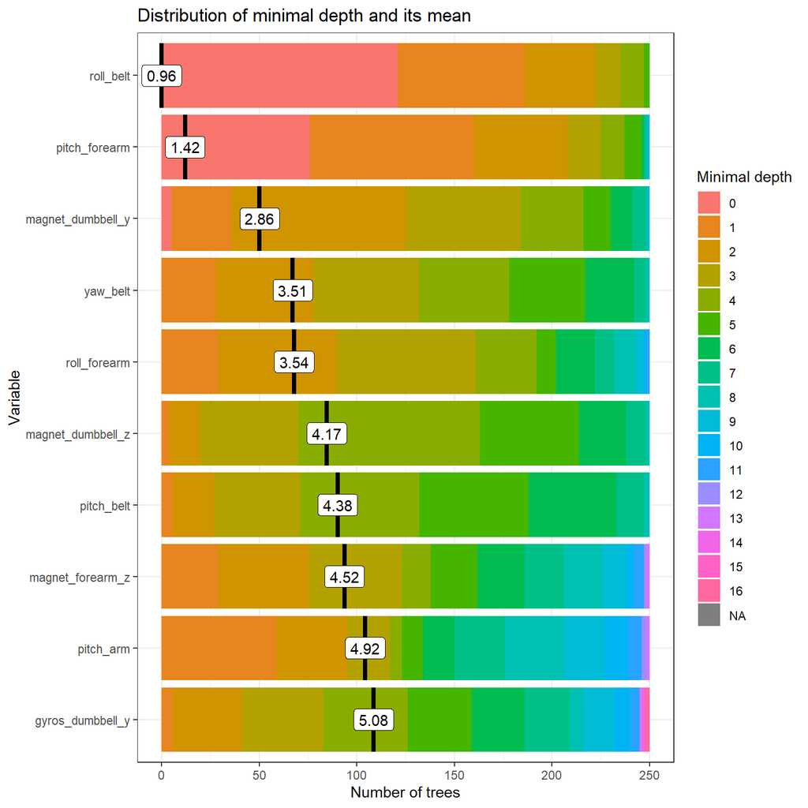